# Reproducible Research Project 1 JHU

## What is mean total number of steps taken per day?

Loading Data

```r
activity<-read.csv("activity.csv")
```

1. Calculate the total number of steps taken per day

```r
library(dplyr)

stepsDate<-activity%>%
        group_by(date)%>%
        summarise(steps=sum(steps))
```

2. Make a histogram of the total number of steps taken each day

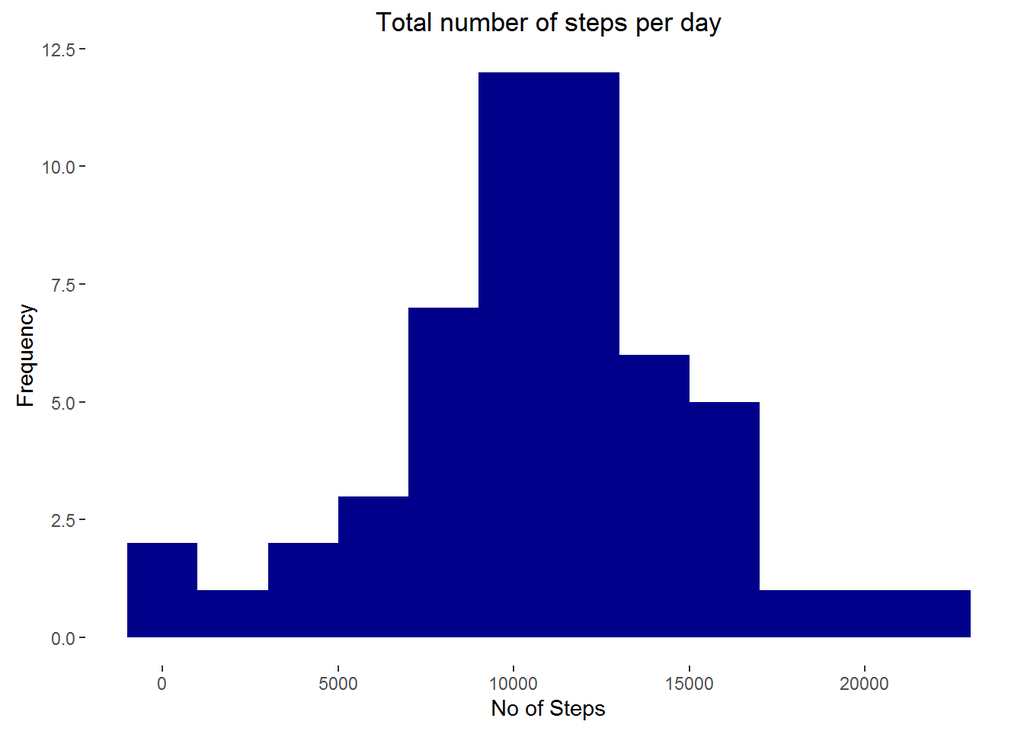

```r
library(ggplot2)

ggplot(stepsDate,aes(steps),gridline=FALSE)+
        geom_histogram(binwidth=2000,fill="blue4")+
        labs(title="Total number of steps per day",x="No of Steps",y="Frequency")+
        theme(panel.background = element_blank())
```

```r
smean<-mean(stepsDate$steps, na.rm = TRUE)
smedian<-median(stepsDate$steps, na.rm = TRUE)
```

## What is the average daily activity pattern?

1. Make a time series plot (i.e. type = “l”) of the 5-minute interval (x-axis) and the average number of steps taken, averaged across all days (y-axis)

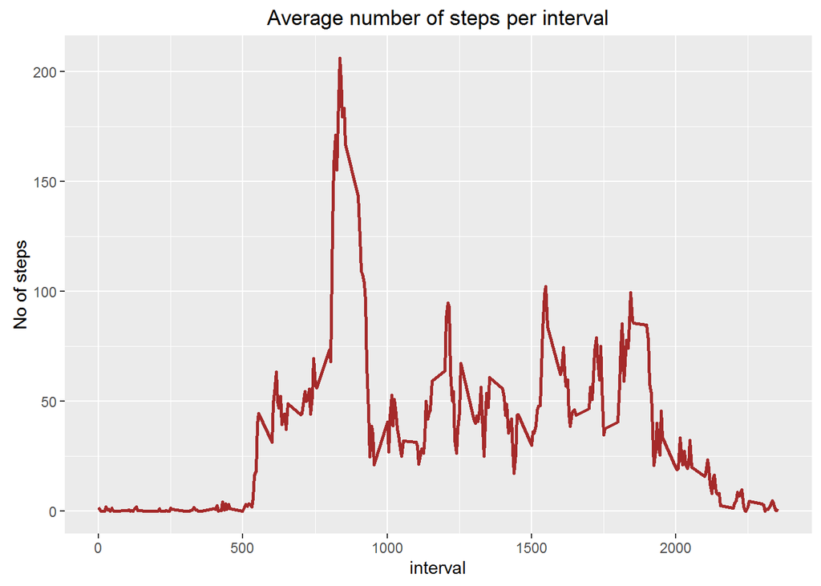

```r
average<-activity%>%
        group_by(interval)%>%
        summarise(averageDay=mean(steps, na.rm=TRUE))

ggplot(average,aes(interval,averageDay))+
        geom_line(linetype=1,color="brown",size=1)+
        labs(title="Average number of steps per interval",y="No of steps")
```

2. Which 5-minute interval, on average across all the days in the dataset, contains the maximum number of steps?

```r
maxInterval<-filter(average,averageDay==max(averageDay))
```

Interval 835 with 206.1698113 number of steps.

## Imputing missing values

1. Calculate and report the total number of missing values in the dataset (i.e. the total number of rows with NAs)

```r
summary(activity)
```

```
##      steps                date          interval
##  Min.   :  0.00   2012-10-01:  288   Min.   :   0.0
##  1st Qu.:  0.00   2012-10-02:  288   1st Qu.: 588.8
##  Median :  0.00   2012-10-03:  288   Median :1177.5
##  Mean   : 37.38   2012-10-04:  288   Mean   :1177.5
##  3rd Qu.: 12.00   2012-10-05:  288   3rd Qu.:1766.2
##  Max.   :806.00   2012-10-06:  288   Max.   :2355.0
##  NA's   :2304     (Other)   :15840
```

```r
naRows<-data.frame(table(!is.na(activity)))
```

Number of rows with NAs is 2304

2. Devise a strategy for filling in all of the missing values in the dataset. The strategy does not need to be sophisticated. For example, you could use the mean/median for that day, or the mean for that 5-minute interval, etc.

The following algorithm replaces the NA´s by steps average by interval:

```r
average<-activity%>%
        group_by(interval)%>%
        summarise(averageDay=mean(steps, na.rm=TRUE))

activityNew<-left_join(activity,average,by="interval")

activityNew<-activityNew%>%
        mutate(steps1=ifelse(is.na(steps),averageDay,steps))%>%
        select(steps1,date,interval)%>%
        rename(steps=steps1)%>%
        mutate(date=as.Date(date))
```

3. Create a new dataset that is equal to the original dataset but with the missing data filled in

```r
average<-activity%>%
        group_by(interval)%>%
        summarise(averageDay=mean(steps, na.rm=TRUE))

activityNew<-left_join(activity,average,by="interval")

activityNew<-activityNew%>%
        mutate(steps1=ifelse(is.na(steps),averageDay,steps))%>%
        select(steps1,date,interval)%>%
        rename(steps=steps1)%>%
        mutate(date=as.Date(date))
head(activityNew)
```

```
##       steps       date interval
## 1 1.7169811 2012-10-01        0
## 2 0.3396226 2012-10-01        5
## 3 0.1320755 2012-10-01       10
## 4 0.1509434 2012-10-01       15
## 5 0.0754717 2012-10-01       20
## 6 2.0943396 2012-10-01       25
```

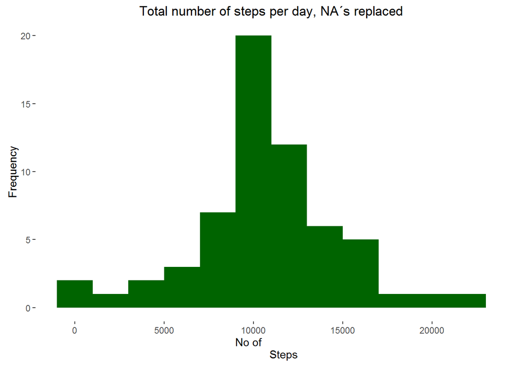

```r
stepsDateNew<-activityNew%>%
        group_by(date)%>%
        summarise(steps=sum(steps))

ggplot(stepsDateNew,aes(steps),gridline=FALSE)+
        geom_histogram(binwidth=2000,fill="darkgreen")+
        labs(title="Total number of steps per day, NA´s replaced",x="No of
        Steps",y="Frequency")+
        theme(panel.background = element_blank())
```

```r
nmean<-mean(stepsDateNew$steps, na.rm = TRUE)
nmedian<-median(stepsDateNew$steps, na.rm = TRUE)
```

## Are there differences in activity patterns between weekdays and weekends?

1. Create a new factor variable in the dataset with two levels - “weekday” and “weekend” indicating whether a given date is a weekday or weekend day.

```r
activityNew$day<-weekdays(activityNew$date)
activityNew$day<-ifelse(activityNew$day=="Saturday" | activityNew$day=="Sunday","weekend","weekday")


head(activityNew)
```

```
##       steps       date interval     day
## 1 1.7169811 2012-10-01        0 weekday
## 2 0.3396226 2012-10-01        5 weekday
## 3 0.1320755 2012-10-01       10 weekday
## 4 0.1509434 2012-10-01       15 weekday
## 5 0.0754717 2012-10-01       20 weekday
## 6 2.0943396 2012-10-01       25 weekday
```

2. Make a panel plot containing a time series plot (i.e. type = “l”) of the 5-minute interval (x-axis) and the average number of steps taken, averaged across all weekday days or weekend days (y-axis). See the README file in the GitHub repository to see an example of what this plot should look like using simulated data.

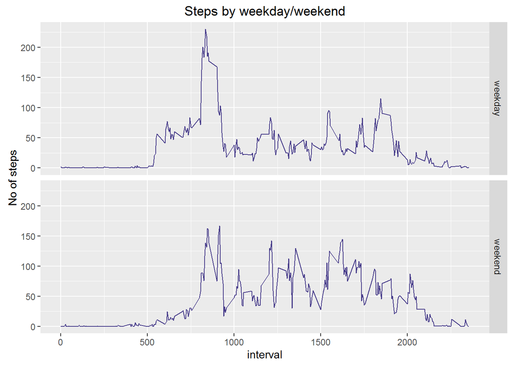

```r
weekActivity<-activityNew%>%
        group_by(interval,day)%>%
        summarise(stepsAverage=mean(steps))

ggplot(weekActivity,aes(interval,stepsAverage))+
        geom_line(color="darkslateblue")+
        facet_grid(day~.)+
        labs(title="Steps by weekday/weekend",y="No of steps")
```